# Housing Forecasting with ARIMA

Haojun Gong

2026-11-23

```r
library(fpp2)
```

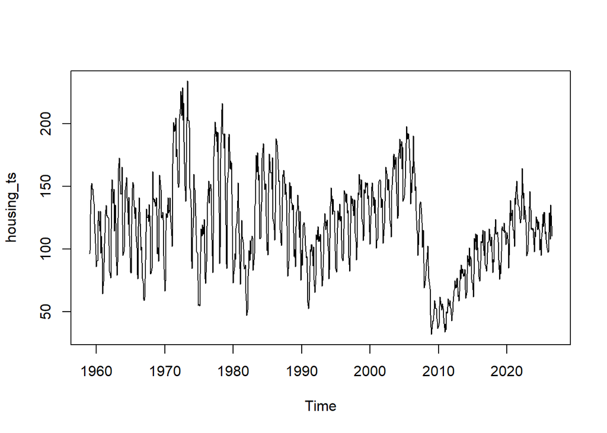

```r
library(forecast)

housing <- read.csv("HOUSTNSA.csv")

housing_ts <- ts(housing$HOUSTNSA, start = c(1959, 1), frequency = 12)
plot(housing_ts)
```

```r
nsdiffs(housing_ts)
```

```
## [1] 1
```

```r
ndiffs(housing_ts)
```

```
## [1] 1
```

```r
ndiffs(diff(housing_ts, 12))
```

```
## [1] 0
```

```r
housing_fit <- auto.arima(housing_ts, trace = TRUE, stepwise = FALSE)
```

[output not shown]

[output cut: 147 more lines]

[output not shown]

```r
housing_fit
```

```
## Series: housing_ts
## ARIMA(3,0,0)(1,1,1)[12]
##
## Coefficients:
##          ar1     ar2     ar3    sar1     sma1
##       0.6276  0.2432  0.0798  0.1208  -0.8846
## s.e.  0.0360  0.0410  0.0353  0.0408   0.0178
##
## sigma^2 = 109.6:  log likelihood = -3019.66
## AIC=6051.32   AICc=6051.43   BIC=6079.43
```

I used auto.arima() and got ARIMA(3,0,0)(1,1,1)[12]. Since my data is monthly, I compared each month’s housing starts with the same month a year earlier. After that, ndiffs() returned 0, so I didn’t need to difference the data again.

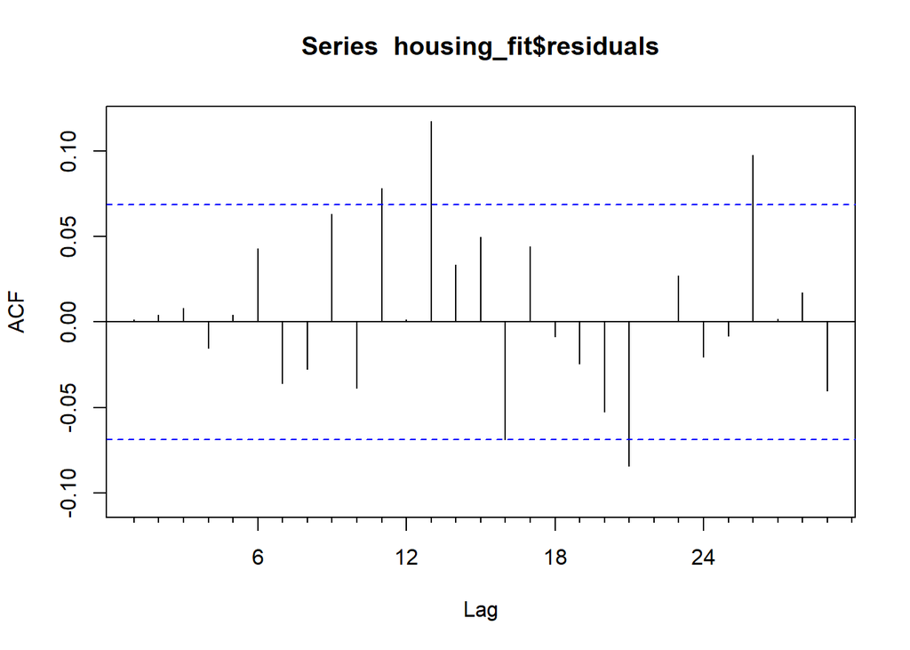

```r
Acf(housing_fit$residuals)
```

```r
Box.test(residuals(housing_fit), lag = 20, type = "Ljung")
```

```
##
##  Box-Ljung test
##
## data:  residuals(housing_fit)
## X-squared = 35.697, df = 20, p-value = 0.01669
```

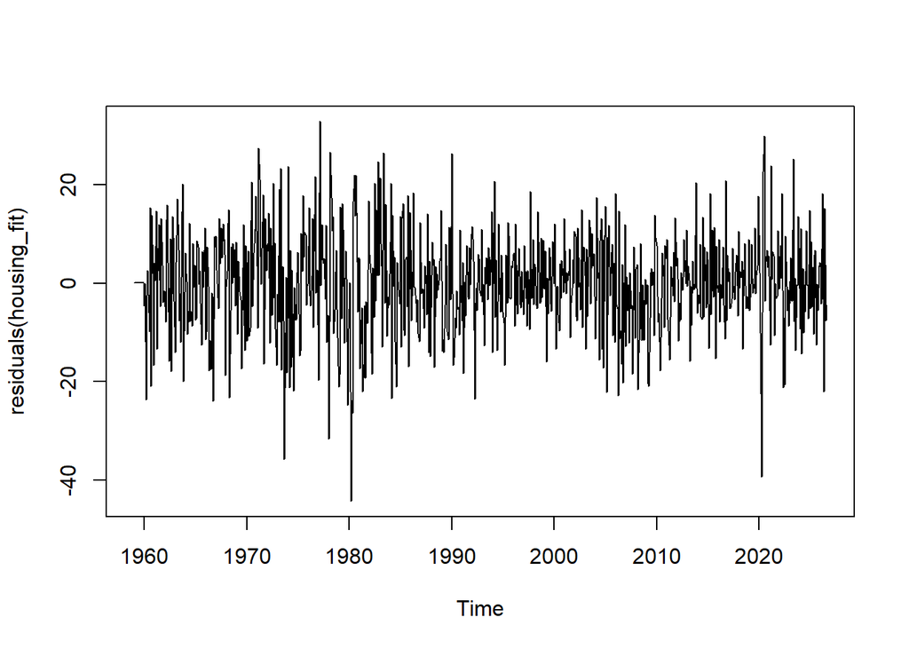

```r
plot.ts(residuals(housing_fit))
```

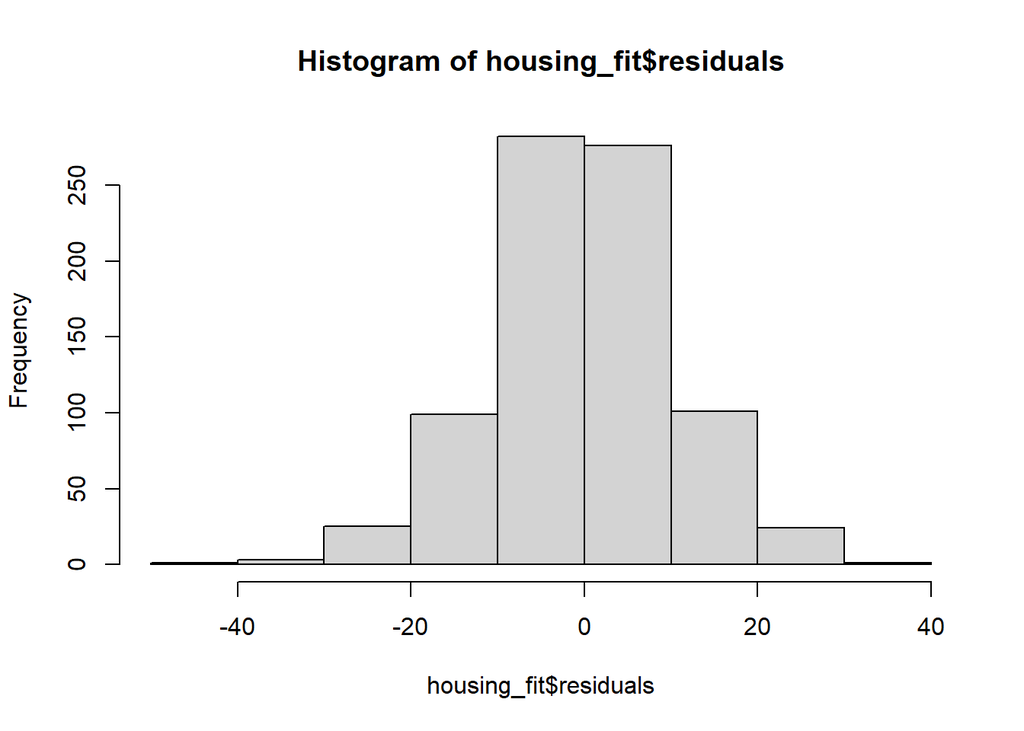

```r
hist(housing_fit$residuals)
```

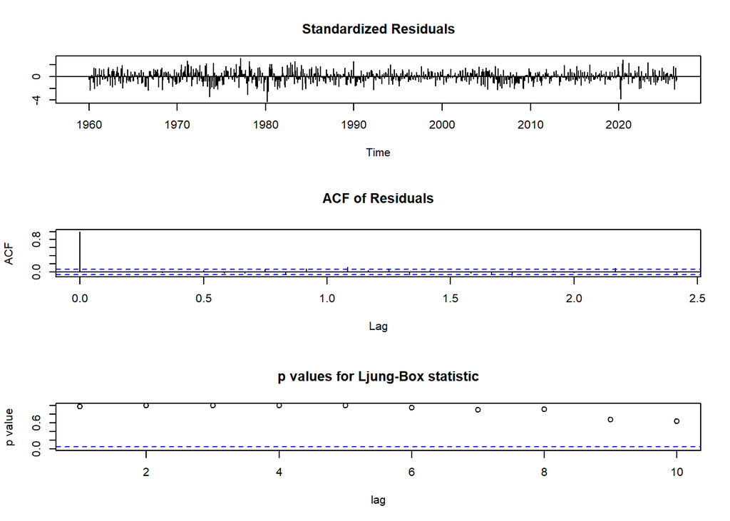

```r
tsdiag(housing_fit)
```

I checked the residual plots and ran the Ljung–Box test at lag 20. The p-value was 0.0167, which is below 0.05. This suggests that the residuals are still correlated, so the model may have missed some patterns in the data.

```r
housing_forecast <- forecast(housing_fit, h = 5, level = c(99.5))
housing_forecast
```

```
##          Point Forecast  Lo 99.5  Hi 99.5
## Sep 2026      111.10668 81.71555 140.4978
## Oct 2026      108.67999 73.98068 143.3793
## Nov 2026       98.63996 59.21101 138.0689
## Dec 2026       93.36462 49.77569 136.9536
## Jan 2027       91.35702 44.31540 138.3986
```

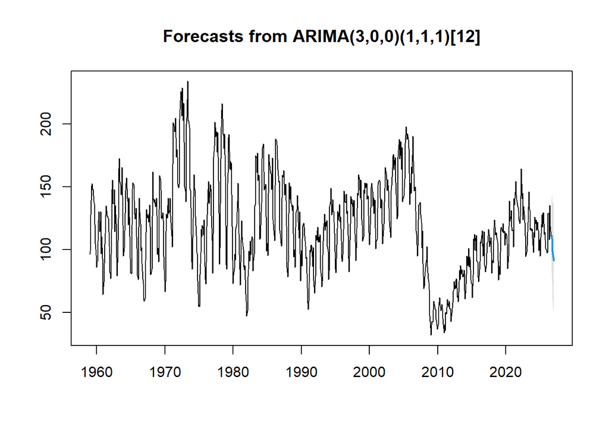

```r
plot(housing_forecast)
```

I forecasted monthly housing starts from September 2026 through January 2027. The forecast decreases each month, from about 111,100 units in September to about 91,400 units in January. The 99.5% prediction intervals get wider for later months, showing more uncertainty farther into the forecast.

```r
accuracy(housing_fit)
```

```
##                       ME     RMSE     MAE        MPE     MAPE      MASE
## Training set -0.08708652 10.36034 8.01527 -0.6587317 7.358435 0.4510531
##                     ACF1
## Training set 0.001474594
```

The model had an MAE of 8.02 thousand units, an RMSE of 10.36 thousand units, and a MAPE of 7.36%. The MAE means that the fitted values were off by about 8,020 housing units per month on average.